# Curtailments

Luis Iberico

2023-01-10

```r
require(rstan)
require(tidyverse)
require(gtools)
require(forecast)
rm(list=ls())

load("data.Rda")
load("TestData.Rda")
```

# Introduction

In this sample project I will show how to build a model for Mortgage Curtailments, and proceed with the estimation of a prepayment curve. The model will be trained using data from 2015 up to 2017, and tested using data from 2018. In banking, the prepayment or behavioral curve is one of the principal components in the Transfer Pricing (TP) -the price that the treasury charges the business for the savings-. The TP is also one of the principal components in the pricing -the price that the Bank charges the clients-. I will use a sample of real data from a bank that I wont disclose. Curtailments have a weird distribution. It has a high concentration of 0’s, a smaller concentration of 1’s, and some density in between. The model that I chose is the Zero One Inflated Beta, which models the empirical distribution very well. The model is estimated in stan (rstan package for r) and follows Ospina and Ferrari 2010.

# Data Description

The data that I am using has 14 features and one target (SMM), and has information on every transaction of each mid to high income clients between 2015 and 2017. Now, I will give a brief description of each variable. The variables were previously chosen according to banking experts and correlation analysis.

- Salary: Monthly salary in PEN (national currency).
- Age: Age (in years) of the client.
- QProd: Total number of products that the client holds.
- ActBal: Active Balance is the total amount of loan that a client holds.
- PassBal: Passive Balance is the total amount of savings that a client holds.
- SOW: Share of Wallet is the proportion (%) of loans that the client holds in this bank with respect to the complete banking system.
- Loan: Total amount of the mortgage loan.
- Rate: Rate of the mortgage loan.
- Maturity: Time (in months) since the start of the mortgage loan.
- Maturity2: Squared maturity.
- DD: The Domestic Demand measures the annualized growth in economic activity of the country (Private and Public expenditure).
- CPI: Consumer Price Index measures the annualized increment in prices.
- HPI: House Price Index measures the annualized increment in housing prices.
- Date: year-month.
- SMM: Curtailments measured as Single Monthly Mortality (SMM) rate. The SMM will be introduced in the next section.

Here is a table that will help understand the structure of the data.

```r
str(DF_train)
```

```
FALSE tibble [3,064 × 15] (S3: tbl_df/tbl/data.frame)
FALSE  $ Salary   : num [1:3064] 7670 4534 12000 13163 30000 ...
FALSE  $ Age      : num [1:3064] 38 35 29 40 42 32 50 38 39 43 ...
FALSE  $ QProd    : num [1:3064] 5 2 4 5 5 4 5 7 6 3 ...
FALSE  $ ActBal   : num [1:3064] 17500 0 169950 194617 240585 ...
FALSE  $ PassBal  : num [1:3064] 28322 25845 2556 26135 1105 ...
FALSE  $ SOW      : num [1:3064] 1 0.897 1 1 0.993 ...
FALSE  $ Loan     : num [1:3064] 87900 67860 160000 220320 310000 ...
FALSE  $ Rate     : num [1:3064] 15.28 11.51 8.97 9.38 8.68 ...
FALSE  $ Maturity : num [1:3064] 15 35 20 16 47 32 85 1 54 15 ...
FALSE  $ Maturity2: num [1:3064] 225 1225 400 256 2209 ...
FALSE  $ DD       : num [1:3064] -2.488 -3.592 1.449 -0.423 -0.76 ...
FALSE  $ CPI      : num [1:3064] 3.91 3.25 3.37 4.3 3.07 ...
FALSE  $ HPI      : num [1:3064] -0.0274 0.0513 -0.0565 -0.0569 -0.0045 ...
FALSE  $ Date     : num [1:3064] 201604 201702 201505 201603 201501 ...
FALSE  $ SMM      : num [1:3064] 1 1 0 0.0942 0 ...
```

# Curtailments

A curtailment is any additional payment that clients make on their mortgage loans. There are two types of curtailments: partial curtailment and full curtailment. A full curtailment means the client payed the full loan. Also, a curtailment can aim to reduce the terms of the loan, or to decrease the monthly payment. This affects the estimation of the Transfer Pricing, but we will ignore them in sake of simplicity.

In this project we measure the curtailment as the Single Monthly Mortality. This is a ratio of the monthly prepayment by the principal. You can find more information on this ratio in [investopedia](https://www.investopedia.com/terms/p/principal.asp).

In short, SMM takes the value of 0 if there is no curtailment, 1 if there is a full curtailment, and some number between 0 and 1 if there is a partial curtailment. In practice, not many clients make partial curtailments, and even less clients make full curtailments, so we have a high concentration of 0’s in the distribution. After doing some research, I came upon a mixture model that can represent this distribution. This model is known as the Zero One Inflated Beta or ZOIB model.

# ZOIB Model

This model consist of a beta model inflated in 0 and 1. This is a mixture model of 3 processes. The first process distinguish if the value is categorical (0 or 1) or continuous (0,1), a binomial density. The second process distinguish if the value, given that its a categorical number, is 0 or 1, another binomial density. And the third process estimates the beta density for the continuous part. Each process can be understood as a model on its own, and this three models run simultaneously, each with its own predictors. For simplicity, I will use the same predictors on each mixture. a great paper with much more information on ZOIB and ZIB models is this one [Opsina & Ferrari 2010](http://dx.doi.org/10.1007/s00362-008-0125-4).

As an example, lets sample from a ZOIB distribution. Let $\alpha$ be the mean parameter for the first binomial component (categorical or continuous), $\gamma$ is the mean parameter for the second binomial component (0 or 1), and $[b_1, b_2]$ the shape parameters of the beta component. The empirical distribution or curtailments has a high concentration of values around 0, so we set $\alpha = 0.7$. The amount of full curtailments is very low, but noticeable, so we set $\gamma = 0.1$. Finally, we have a beta (1,2) distribution.

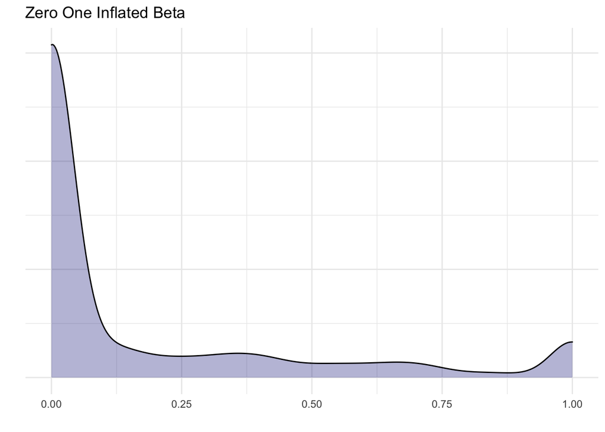

```r
n <- 1000
alpha <- 0.7
gamma <- 0.1
b1 <- 1
b2 <- 2
rzoib <- function(n,alpha,gamma,b1,b2){
  categorical <- rbinom(n,1,alpha)
  one <- rbinom(n,1,gamma)
  ZOIB = rbeta(n,b1,b2)
  ZOIB[categorical*one==1] <- 1
  ZOIB[categorical==1&one==0] <- 0
  return(ZOIB)
}
set.seed(42)
ggplot(,aes(x=rzoib(n,alpha,gamma,b1,b2)))+
  geom_density(fill="navy",color="black",alpha=.3)+
  theme_minimal()+
  labs(x="",y="",title = "Zero One Inflated Beta")+
  theme(axis.text.y=element_blank(),
        axis.ticks.y=element_blank())
```

# Model Fit

The stan code for this ZOIB models is quite large because we have several parameters, and we also want to test the out of sample performance of the model, so we have add that to the sampler. I will break it down in 5 parts.

## Data

Here we declare all the data objects that we are going to use. We need to declare the number of observations (N), the number of features (F), the feature matrix (X), and the target (Y). Also, for the out of sample prediction, we specify the same arguments excluding Y.

## Parameters

Here we declare all the priors and hyper priors that we will use. For each parameter of all the components (4 in total) we specify the gamma and tau hyper priors, and a set of priors for the coefficients. We have 4 components in total: alpha for the mean of the first binomial component, gamma for the mean of the second binomial component, mu for the mean of the beta distribution, and phi for the precision parameter of the beta distribution. It is easier to think of a model on the mean rather than the scale parameters, so we set the model like this and re-parametrise later on.

## Transformed Parameters

Here we declare and calculate the parameters alpha (from the first binomial component), gamma (from the second binomial component), mu (mean of beta), phi (precision of beta), p (first scale of beta), and q (second scale of beta). It is worth noticing that the first three components and the mean of the beta are estimated with a logit link, and the precision is estimated with a log link. The inverse of the link functions are used to estimated the parameters. This is done for the fit and the out of sample prediction.

## Model

Here we populate the hyper priors and priors, and estimate the ZOIB model.

## Generated Quantities

Here we sample Y_fit from the posterior predictive distribution, and we also sample Y_pred which is the output of sample prediction.

```r
ZOIB <- "
data {
  // Fit
  int N;  // N of Obs
  int F;  // N of Features
  matrix[N,F] X; // Matrix of Features
  vector<lower=0, upper=1>[N] Y;
  // Predict
  int N_pred;  // N of Obs
  int F_pred;  // N of Features
  matrix[N_pred,F_pred] X_pred; // Matrix of Features

}

parameters {
  // Hyper Priors
  vector[F] gamma;
  vector<lower=0>[F] tau;

  // alpha function
  vector[F] coef_a; //population-level regression coefficients

  // gamma function
  vector[F] coef_g; //population-level regression coefficients

  // mu function
  vector[F] coef_m; //population-level regression coefficients

  // phi function
  vector[F] coef_p; //population-level regression coefficients
}

transformed parameters {
  // Fit
  vector<lower=0, upper=1>[N] p1;
  vector<lower=0, upper=1>[N] p2;
  vector[N] mu;
  vector<lower=0>[N] phi;
  vector<lower=0>[N] p;
  vector<lower=0>[N] q;

  // Predict
  vector<lower=0, upper=1>[N_pred] p1_pred;
  vector<lower=0, upper=1>[N_pred] p2_pred;
  vector[N_pred] mu_pred;
  vector<lower=0>[N_pred] phi_pred;
  vector<lower=0>[N_pred] p_pred;
  vector<lower=0>[N_pred] q_pred;

  // Compute the linear predictor using relevant group-level regression coefficients

    // Fit
    p1 = inv_logit(X * coef_a);
    p2 = inv_logit(X * coef_g);
    mu = inv_logit(X * coef_m);
    phi = exp(X * coef_p);
    p = mu .* phi;
    q = phi - mu .* phi;

    // Pred
    p1_pred = inv_logit(X_pred * coef_a);
    p2_pred = inv_logit(X_pred * coef_g);
    mu_pred = inv_logit(X_pred * coef_m);
    phi_pred = exp(X_pred * coef_p);
    p_pred = mu_pred .* phi_pred;
    q_pred = phi_pred - mu_pred .* phi_pred;

}

model {
  // Hyper priors
  gamma ~ normal(0,5);
  tau ~ cauchy(0,2.5);

  // Fill the matrix of group-level regression coefficients

   coef_a ~ normal(gamma,tau);
   coef_g ~ normal(gamma,tau);
   coef_m ~ normal(gamma,tau);
   coef_p ~ normal(gamma,tau);



  // zero one inflated beta likelihood
  for (i in 1:N) {
    if (Y[i] == 0) {
      target += log(p1[i]) + log1m(p2[i]);
    } else if (Y[i] == 1) {
      target += log(p1[i]) + log(p2[i]);
    } else {
      target += log1m(p1[i]) + beta_lpdf(Y[i] | p[i], q[i]);
    }
  }
}


generated quantities {

  vector[N] y_est;
  real is_cat;
  real is_1;

  for (i in 1:N) {
  is_cat = binomial_rng(1, p1[i]);
  is_1 = binomial_rng(1, p2[i]);

    if (is_cat == 1) {
      if (is_1 == 0) {
        y_est[i] = 0;
      }
      else {
        y_est[i] = 1;
      }
    } else {
      y_est[i] = beta_rng(p[i], q[i]);
    }
  }

  vector[N_pred] y_pred;
  real is_cat_pred;
  real is_1_pred;

  for (i_pred in 1:N_pred) {
  is_cat_pred = binomial_rng(1, p1_pred[i_pred]);
  is_1_pred = binomial_rng(1, p2_pred[i_pred]);

    if (is_cat_pred == 1) {
      if (is_1_pred == 0) {
        y_pred[i_pred] = 0;
      }
      else {
        y_pred[i_pred] = 1;
      }
    } else {
      y_pred[i_pred] = beta_rng(p_pred[i_pred], q_pred[i_pred]);
    }
  }




}

"
```

After writing the stan code, we create the data objects that will fill the model.

```r
# Fit
X <- DF_train%>%transmute(Intercept=1,Salary, QProd, ActBal, PassBal, Loan,
                          Rate, Maturity, Maturity2, DD, CPI, HPI)
X <- as.matrix(scale(X))
X[,"Intercept"] <- 1
Y <- DF_train%>%pull(SMM)
# Out of sample prediction
X_pred <- DF_test%>%transmute(Intercept=1,Salary, QProd, ActBal, PassBal, Loan,
                              Rate, Maturity, Maturity2, DD, CPI, HPI)
X_pred <- as.matrix(scale(X_pred))
X_pred[,"Intercept"] <- 1
Y_pred <- DF_test%>%pull(SMM)
```

And here we fit the stan model. We will keep it short to avoid higher computing times, so we use 1,000 samples and 4 chains.

```r
iter <- 1000
chains <- 4
zoibFit <- stan(model_code = ZOIB,
                data = list(N = nrow(X), N_pred=nrow(X_pred),
                            F=ncol(X), F_pred=ncol(X_pred),
                            X=X, X_pred=X_pred,Y=Y),
                iter=iter,
                chains = chains,
                cores=4,
                init=0)
```

```
FALSE Trying to compile a simple C file
```

# Posterior Inference

Here, I build a function to give a better structure to the samples from the stanfit.

```r
list_of_draws <- rstan::extract(zoibFit)

posteriorDraws_fun <-
function(s,c,varlist,draws){
  n <- c*s
  nvar <- length(varlist)
  PosteriorDraws <- matrix(NA,nrow=(n),ncol=(nvar+2))
  PosteriorDraws[,1:nvar] <- draws
  PosteriorDraws[,(nvar+1)] <- rep(c(1:s),c)
  PosteriorDraws[,(nvar+2)] <- c(rep(1,s),rep(2,s),rep(3,s),rep(4,s))
  colnames(PosteriorDraws) <- c(varlist,"Sample","chain")
  PosteriorDraws <- as.data.frame(PosteriorDraws)
  return(PosteriorDraws)
}
varlist <- c("Intercept","Salary", "QProd", "ActBal", "PassBal", "Loan", "Rate", "Maturity", "Maturity2", "DD", "CPI", "HPI")
s <- iter/2

Alpha_posterior <-
posteriorDraws_fun(s=s,c=chains,varlist=varlist,draws=list_of_draws$coef_a)
Gamma_posterior <-
posteriorDraws_fun(s=s,c=chains,varlist=varlist,draws=list_of_draws$coef_g)
Mu_posterior <-
posteriorDraws_fun(s=s,c=chains,varlist=varlist,draws=list_of_draws$coef_m)
```

After fitting the model, the first thing that we have to check is that the samples are not autocorrelated. This can be done graphically by analysing the trace plot. In short, we want to see white noise in the plots for each chain. Then, we can also check the posterior distribution of the coefficients. I define two functions that will plot the graphs for me.

```r
trace_plot <- function(df){
  p <-
  df%>%
  pivot_longer(!c("Sample","chain"))%>%
  ggplot(aes(x=Sample,y=value,color=as.factor(chain)))+
  geom_line(alpha=0.4)+facet_wrap(~name,scales = "free")+
  labs(color="Chain",x="",y="")
  return(p)
}

density_plot <- function(df){
  p <-
  df%>%
  pivot_longer(!c("Sample","chain"))%>%
  ggplot(aes(x=value))+
  geom_density(alpha=0.4,fill="navy")+facet_wrap(~name,scales = "free")+
    labs(x="",y="")
  return(p)
}
```

There are a lot of parameters, so I will focus on the mean fucntion of the beta distribution. We can see from the plot that the chains look mostly the same for each variable, and that the samples do not have autocorrelation. In a similar manner, the posterior distribution is unimodal an resembles a normal distribution. The other parameters have very similar characteristics.

### Traceplots Mean Function (Beta)

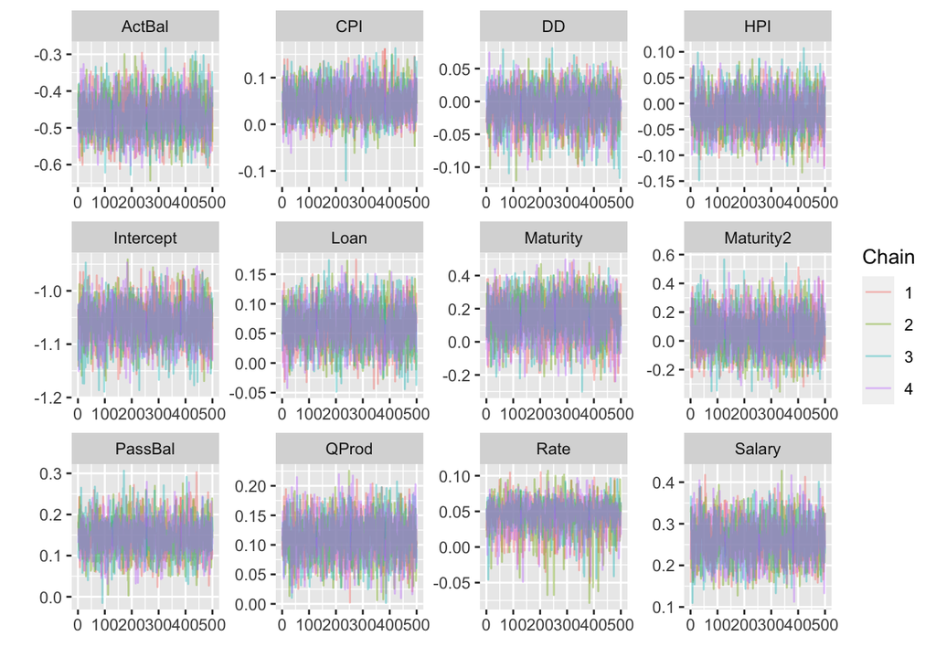

```r
trace_plot(Mu_posterior)
```

### Density Mean Function (Beta)

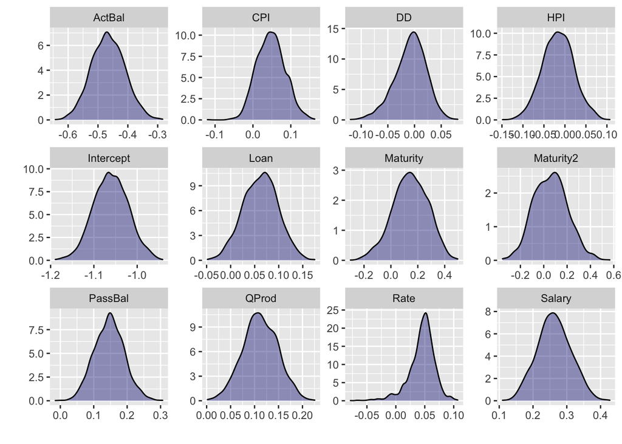

```r
density_plot(Mu_posterior)
```

## Interpretation

This model has three components, so I will split the interpretation in those. Note that we have use the same features to model each component, but you can also have different functions for each component. Also, another way of analysing the convergence of your samples is by using the Rhat. If chains have mixed well, then you will have an Rhat closer to 1. More information on the Rhat can be found [here](https://mc-stan.org/rstan/reference/Rhat.html).

### Alpha component

```r
alpha_summary <- summary(zoibFit, pars = c("coef_a"), probs = c(0.025, 0.975))$summary
rownames(alpha_summary) <- varlist


print(alpha_summary)
```

```
FALSE                   mean     se_mean         sd        2.5%       97.5%     n_eff
FALSE Intercept  0.768345968 0.001143299 0.04193517  0.68648746  0.84901048 1345.3550
FALSE Salary     0.042015375 0.001316745 0.05227146 -0.04938150  0.15227501 1575.8891
FALSE QProd     -0.152989521 0.001008356 0.04265257 -0.23558685 -0.07037280 1789.2157
FALSE ActBal     0.426160404 0.001774855 0.06447298  0.30585368  0.54607671 1319.5623
FALSE PassBal    0.162020705 0.001255092 0.05312224  0.06363203  0.27272776 1791.4382
FALSE Loan      -0.429782285 0.001594462 0.05735336 -0.54485505 -0.32171086 1293.8660
FALSE Rate      -0.022169491 0.001696719 0.04623001 -0.11084073  0.06522367  742.3829
FALSE Maturity   0.951682118 0.006352474 0.16678777  0.65616879  1.29900106  689.3544
FALSE Maturity2 -0.304580877 0.006552578 0.17381511 -0.65880168  0.01385173  703.6403
FALSE DD         0.017961584 0.001158553 0.03363459 -0.04489795  0.08863709  842.8313
FALSE CPI       -0.009064043 0.001388306 0.04238625 -0.09033578  0.07763868  932.1363
FALSE HPI       -0.179519218 0.001183904 0.04345309 -0.26609130 -0.09105620 1347.1263
FALSE                Rhat
FALSE Intercept 0.9996621
FALSE Salary    0.9994735
FALSE QProd     1.0008529
FALSE ActBal    1.0020445
FALSE PassBal   0.9999201
FALSE Loan      1.0021339
FALSE Rate      1.0050605
FALSE Maturity  1.0027704
FALSE Maturity2 1.0019771
FALSE DD        1.0010115
FALSE CPI       0.9991292
FALSE HPI       0.9999620
```

### Gamma component

The gamma component is the binomial distribution that samples between a full prepayment (1) or no prepayment (0). A positive coefficient is interpreted as being more likely to have a full prepayment, conditional on being a “categorical” draw. Then, for example, higher housing prices (HPI) are usually followed by more full curtailments, but higher consumer prices (more inflation), is followed by less curtailments.

```r
gamma_summary <- summary(zoibFit, pars = c("coef_g"), probs = c(0.025, 0.975))$summary
rownames(gamma_summary) <- varlist


print(gamma_summary)
```

```
FALSE                   mean     se_mean         sd        2.5%       97.5%     n_eff
FALSE Intercept -3.640145897 0.005814294 0.19848191 -4.03677644 -3.26218874 1165.3270
FALSE Salary     0.237610200 0.001642962 0.06715366  0.12018787  0.39008283 1670.6448
FALSE QProd     -0.298782403 0.002664677 0.09250060 -0.47718965 -0.12252954 1205.0357
FALSE ActBal    -3.533194661 0.008306979 0.27802249 -4.08183507 -3.00463569 1120.1434
FALSE PassBal    0.379014547 0.002415993 0.10106876  0.18183334  0.57889916 1750.0175
FALSE Loan       0.569403358 0.003242144 0.12927330  0.31992908  0.82104840 1589.8385
FALSE Rate       0.091100064 0.007074518 0.11947573 -0.05129189  0.41832959  285.2106
FALSE Maturity  -0.195766692 0.011372030 0.28774779 -0.82660494  0.33552296  640.2477
FALSE Maturity2  0.044373016 0.009859344 0.24425817 -0.39390168  0.56509617  613.7651
FALSE DD        -0.007280552 0.001953909 0.05470978 -0.13748275  0.09080276  784.0092
FALSE CPI       -0.225447986 0.003375620 0.09479163 -0.40652764 -0.03616521  788.5566
FALSE HPI        0.473695162 0.003052031 0.09817701  0.28205211  0.66833216 1034.7649
FALSE                Rhat
FALSE Intercept 1.0027952
FALSE Salary    0.9990483
FALSE QProd     1.0055200
FALSE ActBal    0.9999180
FALSE PassBal   1.0025251
FALSE Loan      1.0001143
FALSE Rate      1.0048046
FALSE Maturity  1.0028319
FALSE Maturity2 1.0027724
FALSE DD        1.0014502
FALSE CPI       1.0029611
FALSE HPI       1.0004142
```

### Beta component

The beta component is the beta distribution that samples partial curtailments. A positive coefficient is interpreted as having a higher curtailment, conditional on “having a curtailment”. Then, for example, clients with higher salaries and more savings have higher curtailments, while clients with more debts (on other products) have lower curtailments. Also, more expensive loans (higher rates) are correlated with higher curtailments.

```r
mu_summary <- summary(zoibFit, pars = c("coef_m"), probs = c(0.025, 0.975))$summary
rownames(mu_summary) <- varlist


print(mu_summary)
```

```
FALSE                   mean      se_mean         sd         2.5%       97.5%
FALSE Intercept -1.060629835 0.0011468977 0.04009963 -1.138911333 -0.97957955
FALSE Salary     0.262460719 0.0014560330 0.05002524  0.166179378  0.35973571
FALSE QProd      0.111754109 0.0008897933 0.03641267  0.041040673  0.18316528
FALSE ActBal    -0.465776517 0.0016417283 0.05560795 -0.571392738 -0.35488869
FALSE PassBal    0.146422138 0.0011659611 0.04478158  0.061561600  0.23754890
FALSE Loan       0.062139926 0.0011666226 0.03625016 -0.009713996  0.13135535
FALSE Rate       0.044970887 0.0008581392 0.02242591 -0.010175145  0.08132289
FALSE Maturity   0.143373437 0.0053219917 0.13035454 -0.130532768  0.37891293
FALSE Maturity2  0.059898271 0.0059003556 0.14500232 -0.210952835  0.35036409
FALSE DD        -0.007889569 0.0009596287 0.02966522 -0.071951234  0.04581603
FALSE CPI        0.047610877 0.0010865339 0.03688598 -0.018748071  0.12232764
FALSE HPI       -0.016215745 0.0010989223 0.03744450 -0.089313181  0.05927778
FALSE               n_eff      Rhat
FALSE Intercept 1222.4506 1.0011409
FALSE Salary    1180.4183 0.9988959
FALSE QProd     1674.6603 0.9990319
FALSE ActBal    1147.2847 0.9997349
FALSE PassBal   1475.1313 1.0007506
FALSE Loan       965.5152 1.0014316
FALSE Rate       682.9432 1.0009797
FALSE Maturity   599.9347 1.0030384
FALSE Maturity2  603.9397 1.0019177
FALSE DD         955.6280 1.0013148
FALSE CPI       1152.4870 1.0037912
FALSE HPI       1161.0263 1.0025268
```

# Posterior Simulations

In this final section we analyse the fit and out of sample performance of the model. The first plot is the posterior distribution of the curtilments (SMM). This shows how the posterior distributions are similar to the observed.

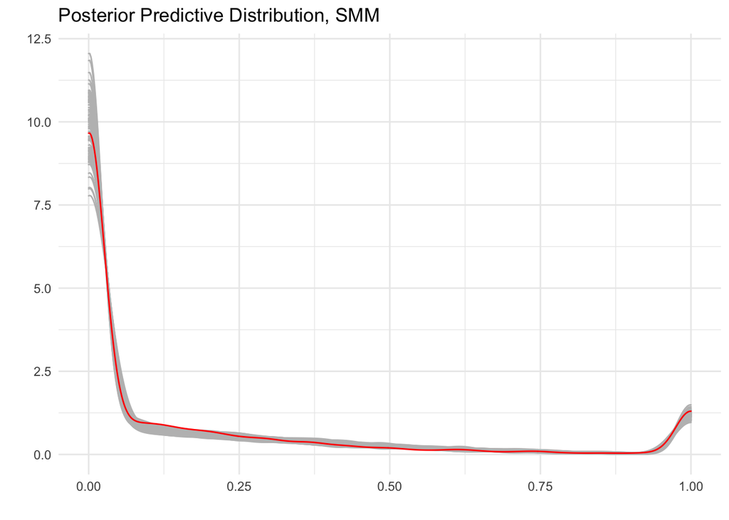

```r
Y_ppd <- t(list_of_draws$y_est)
Y_ppd_mean <- rep(0,nrow(Y_ppd))
for(i in 1:nrow(Y_ppd)){
  Y_ppd_mean[i] <- mean(Y_ppd[i,],na.rm = T)
}

Y_ppd_s <- as.data.frame(Y_ppd[,1:100])%>%
  mutate(Maturity = DF_train$Maturity)%>%
  pivot_longer(!Maturity)

  ggplot()+
  geom_density(data=Y_ppd_s,aes(x=value,color=name),alpha=0.5,size=0.5)+
  geom_density(aes(x=DF_train$SMM),alpha=0.5,size=0.5,color="red")+
  theme_minimal()+
  scale_color_manual(values=rep("gray",100))+
  theme(legend.position = "none")+
  labs(title="Posterior Predictive Distribution, SMM",x="",y="")
```

Anyway, what we really needs is the prepayment curve. This is, on each month of maturity, how much was the curtailment. This next plot compares the observed prepayment curve with the curve from the mean PPD. Both are quite noisy, but are very similar.

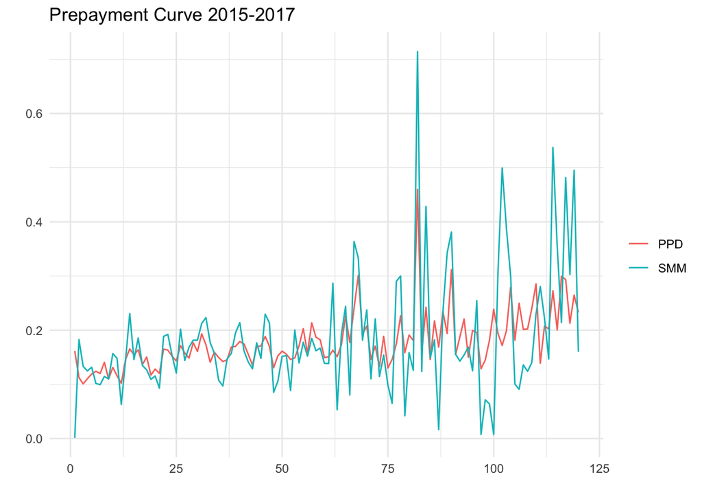

```r
DF_train%>%
  transmute(Maturity,SMM,PPD=Y_ppd_mean)%>%
  group_by(Maturity)%>%
  summarise_all(mean)%>%
  pivot_longer(!Maturity)%>%
  ggplot()+geom_line(aes(x=Maturity,color=name,y=value))+
  theme_minimal()+
  labs(x="",y="",color="",title = "Prepayment Curve 2015-2017")
```

In a similar way, here is the density plot for the our of sample data (2018). The fit is not perfect, and we can clearly see that we are overestimating the amount of 0’s in the model.

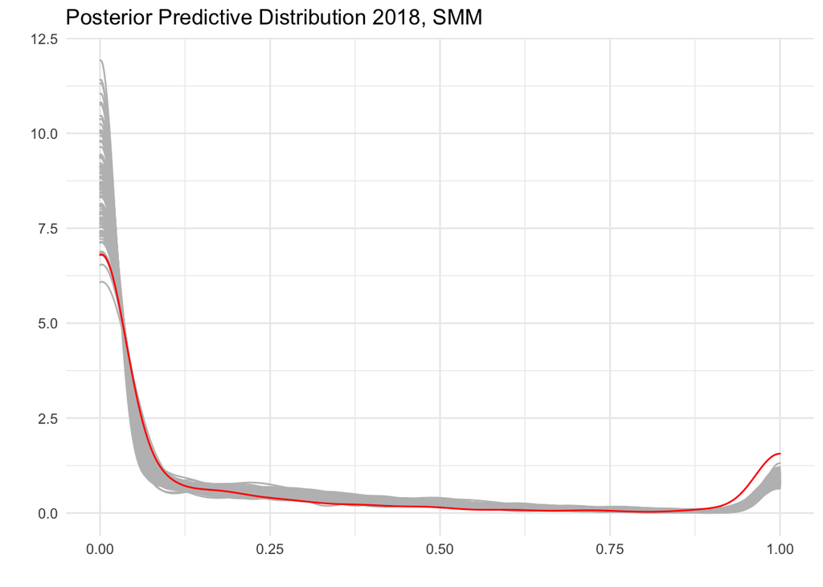

```r
Y_ppd_fc <- t(list_of_draws$y_pred)
Y_ppd_mean_fc <- rep(0,nrow(Y_ppd_fc))
for(i in 1:nrow(Y_ppd_fc)){
  Y_ppd_mean_fc[i] <- mean(Y_ppd_fc[i,],na.rm = T)
}

Y_ppd_fc_s <- as.data.frame(Y_ppd_fc[,1:100])%>%
  mutate(Maturity = DF_test$Maturity)%>%
  pivot_longer(!Maturity)

  ggplot()+
  geom_density(data=Y_ppd_fc_s,aes(x=value,color=name),alpha=0.5,size=0.5)+
  geom_density(aes(x=DF_test$SMM),alpha=0.5,size=0.5,color="red")+
  theme_minimal()+
  scale_color_manual(values=rep("gray",100))+
  theme(legend.position = "none")+
  labs(title="Posterior Predictive Distribution 2018, SMM",x="",y="")
```

And here is the comparison between the predictions for 2018 and the real prepayment curve of that year. Again, we can see that the predictions are not perfect, but they do a good job on predicting the future.

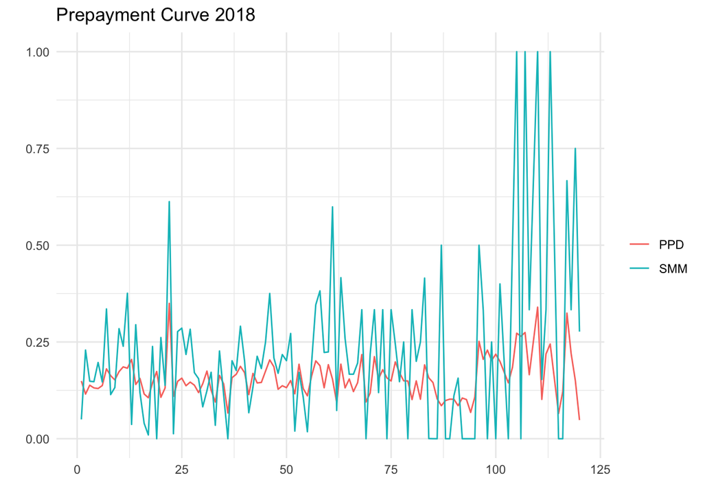

```r
DF_test%>%
  transmute(Maturity,SMM,PPD=Y_ppd_mean_fc)%>%
  group_by(Maturity)%>%
  summarise_all(mean)%>%
  pivot_longer(!Maturity)%>%
  ggplot()+geom_line(aes(x=Maturity,color=name,y=value))+
  theme_minimal()+
  labs(x="",y="",color="",title = "Prepayment Curve 2018")
```

## Predictive Performance

Finally, we can measure how good we are at predicting the prepayments of the following year. I choose to use the Mean Absolute Error (MAE) to avoid over weighting outliers, and I also compute the Mean Relative Absolute Error (MRAE) which is just the MAE divided by the mean value of the target (SMM). As expected, the forecast error is higher than the fit error, but it is a more reasonable measurement for future forecasts.

```r
DF_train%>%
  transmute(Maturity,SMM,PPD=Y_ppd_mean)%>%
  group_by(Maturity)%>%
  summarise_all(mean)%>%
  mutate(DF = "Train")%>%
  bind_rows(
  DF_test%>%
  transmute(Maturity,SMM,PPD=Y_ppd_mean_fc)%>%
  group_by(Maturity)%>%
  summarise_all(mean)%>%
  mutate(DF = "Test"))%>%
  ungroup()%>%group_by(DF)%>%
  transmute(MAE = abs(SMM-PPD),SMM)%>%
  summarise(MAE = mean(MAE),SMM=mean(SMM))%>%
  mutate(MRAE = MAE/SMM)
```

```
FALSE # A tibble: 2 × 4
FALSE   DF       MAE   SMM  MRAE
FALSE   <chr>  <dbl> <dbl> <dbl>
FALSE 1 Test  0.134  0.223 0.598
FALSE 2 Train 0.0579 0.183 0.316
```